# BIOINPUTS AS A SUSTAINABLE STRATEGY FOR RICE AND COMMON BEAN PRODUCTION: IMPLICATIONS FOR PLANETARY HEALTH AND NUTRITION

<sup>1</sup>Wilhan Valasco dos Santos [iD](https://orcid.org/0000-0002-6533-2407), <sup>2</sup>Ana Paula Silva Siqueira, <sup>2</sup>Rita de Cássia Nogueira de Moura [iD](https://orcid.org/0009-0003-5508-0829), <sup>2</sup>Maria Luiza Ferreira de Sousa e Silva [iD](https://orcid.org/0009-0009-3474-5530)

<sup>1</sup>Goiano Federal Institute of Education, Science and Technology – Rio Verde Campus

<sup>2</sup>Goiano Federal Institute of Education, Science and Technology – Urutaí Campus

## *2.7 Exploratory analysis and statistical modeling*

Conduziu-se, neste estudo, uma síntese descritiva de dados de literatura sobre o uso de bioinsumos microbianos (bactérias, fungos e a combinação fungo mais bactéria) em feijão (*Phaseolus vulgaris*) e arroz (*Oryza sativa*), comparados a um controle sem inoculação. A unidade de observação é o registro experimental individual, identificado por cada estudo/artigo, e cada estudo pode contribuir com várias observações para a mesma classe e variável, de modo que o número de observações não equivale ao número de unidades independentes; por isso, toda tabela informa observações e estudos distintos, sendo o segundo o indicador de robustez de cada comparação.

A base utilizada (3.404 linhas, 76 estudos) é a versão tratada da revisão de literatura, na qual cultura e classe de cada registro foram atribuídas por curadoria manual do autor, conforme a Table 1, e não por correspondência automática de palavras-chave. Essa curadoria distingue bactéria, fungo, fungo mais bactéria e controle. Outras categorias presentes na base, como extratos vegetais, derivados biológicos ou orgânicos, fertilizantes minerais, comparadores químicos e condições experimentais diversas, não integram este estudo. Um pequeno número de valores exatamente iguais a zero foi identificado em algumas variáveis; não havia evidência documental de que representassem lacuna de preenchimento e, por isso, foram mantidos como observações válidas, sem conversão automática para dado ausente.

Table 1. Composição amostral por cultura e classe, antes da aplicação dos critérios de disponibilidade por variável.

| Cultura | Classe | Número de observações | Número de estudos |
| --- | --- | --- | --- |
| Feijão | Controle | 239 | 25 |
| Feijão | Bactéria | 130 | 5 |
| Arroz | Controle | 414 | 46 |
| Arroz | Bactéria | 735 | 14 |
| Arroz | Fungo | 121 | 5 |
| Arroz | Fungo + Bactéria | 54 | 2 |

Número de observações: registros experimentais individuais. Número de estudos: contagem de códigos de identificação (ID) distintos. Classes sem nenhuma observação válida na cultura correspondente não são apresentadas.

As variáveis analisadas cobrem emergência, crescimento vegetativo e desempenho reprodutivo ou produtivo, e o conjunto usado em cada cultura foi definido pela disponibilidade real de dados (Table 2), não por critério fixo igual às duas espécies.

Table 2. Número total de observações e de estudos disponíveis para cada variável, por cultura.

| Cultura | Variável | Nº observações | Nº estudos |
| --- | --- | --- | --- |
| Feijão | Altura de planta (cm) | 112 | 8 |
| Feijão | Massa fresca da parte aérea (g planta⁻¹) | 68 | 3 |
| Feijão | Massa seca da parte aérea (g planta⁻¹) | 89 | 5 |
| Feijão | Massa fresca de raízes (g planta⁻¹) | 61 | 3 |
| Feijão | Número de vagens (planta⁻¹) | 51 | 4 |
| Feijão | Produtividade (kg ha⁻¹) | 76 | 6 |
| Arroz | Germinação (%) | 156 | 7 |
| Arroz | Altura de planta (cm) | 307 | 21 |
| Arroz | Comprimento de raiz (cm) | 377 | 12 |
| Arroz | Número de perfilhos (planta⁻¹) | 86 | 7 |
| Arroz | Número de panículas (planta⁻¹) | 51 | 3 |
| Arroz | Produtividade (kg ha⁻¹) | 293 | 7 |
| Arroz | Controle de doença (%) | 56 | 4 |
| Arroz | Carbono orgânico (g kg⁻¹) | 80 | 3 |
| Arroz | Redução de fertilizantes (%) | 240 | 6 |

Numeric values were converted while preserving the original decimal separator and measurement units, and empty cells were treated as missing data. For each combination of crop, class, and variable, the number of observations and studies, mean, standard deviation, median, quartiles, and range were calculated, requiring at least two observations for the standard deviation; combinations without valid observations are not shown in the tables. Because many classes comprise few studies with multiple observations each, the independence assumption required for a formal confidence interval is not met in this dataset. Dispersion is therefore described using standard deviation, median, and quartiles, without inferential intent. The difference between each class and the control was expressed as the percentage change in the class median relative to the control median, according to the equation

$$\Delta_{\%} = 100 \times \frac{\widetilde{x}_{\mathrm{classe}} -
\widetilde{x}_{\mathrm{controle}}}{\widetilde{x}_{\mathrm{controle}}},$$

restricted to combinations with at least three observations per class. Instead of an inferential confidence interval, horizontal bars represent the first and third quartiles (Q1 and Q3) of each compared class, also expressed as percentage change relative to the control median. This range describes within-class dispersion without distributional assumptions, standard errors, or study-level pairing. Multivariate association was explored using principal component analysis, with standardization and median imputation restricted to this analysis. Exclusively for the rice PCA, observations presenting at least one value below Q1 − 1.5 × IQR or above Q3 + 1.5 × IQR among eligible variables were removed.

All statistical analyses were conducted in the R computing environment using fully reproducible procedures (R Core Team, 2026), with the *`dplyr`* (Wickham et al., 2026) and *`tidyr`* (Wickham, Vaughan, and Girlich, 2026) packages. Graphical visualizations were produced with *`ggplot2`* (Wickham, 2016), while figure-panel composition was performed with *`patchwork`* (Pedersen, 2025). Tables and the dynamic report were generated with the *`knitr`* package (Xie, 2025).

# 1 Results

## 1.1 Geographic distribution of studies

[figure not shown]

**Figure 1.** Distribuição geográfica dos 76 estudos incluídos na síntese. Os círculos indicam os países de realização; o tamanho é proporcional ao número de estudos distintos e o valor interno apresenta a frequência por país.

## 1.2 Temporal evolution of scientific production

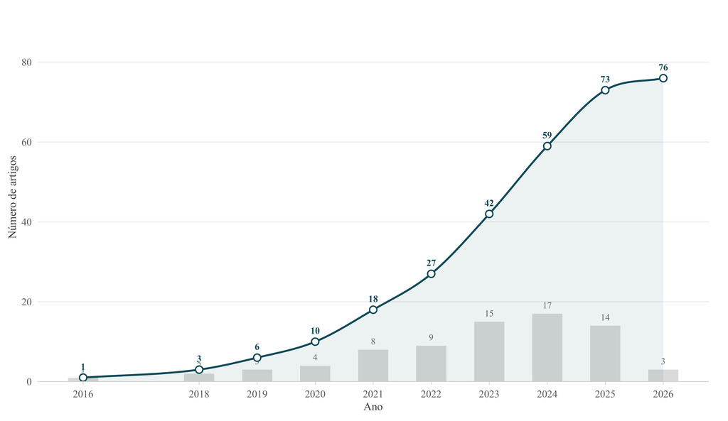

**Figure 2.** Número de artigos publicados por ano (barras cinzas, eixo compartilhado) e número acumulado de artigos (linha e círculos azul-petróleo) sobre bioinsumos microbianos em feijão e arroz, de 2016 a 2026, totalizando 76 artigos; o artigo identificado para o ano de 2015 foi excluído do estudo. A linha conecta os valores acumulados observados a cada ano por interpolação monotônica; os números junto a cada ponto indicam o total acumulado naquele ano, e os números junto a cada barra indicam a frequência anual.

## 1.3 Descriptive statistics

### 1.3.1 Common bean

Table 3. Descriptive statistics of agronomic variables in common bean, by class.

| Variável | Classe | Nº obs. | Nº estudos | Média | Desvio-padrão | Mediana | Q1 | Q3 | Mínimo | Máximo |
| --- | --- | --- | --- | --- | --- | --- | --- | --- | --- | --- |
| Altura de planta (cm) | Controle | 45 | 8 | 28,68 | 16,92 | 20,50 | 16,00 | 35,30 | 0,00 | 73,75 |
| Altura de planta (cm) | Bactéria | 67 | 2 | 47,10 | 9,87 | 51,37 | 39,00 | 53,70 | 26,00 | 59,36 |
| Massa fresca da parte aérea (g planta⁻¹) | Controle | 28 | 3 | 21,65 | 33,96 | 1,67 | 0,63 | 38,20 | 0,52 | 93,97 |
| Massa fresca da parte aérea (g planta⁻¹) | Bactéria | 40 | 1 | 115,63 | 46,16 | 117,85 | 59,16 | 148,30 | 55,10 | 183,50 |
| Massa seca da parte aérea (g planta⁻¹) | Controle | 31 | 5 | 3,42 | 5,00 | 0,42 | 0,23 | 6,66 | 0,13 | 13,84 |
| Massa seca da parte aérea (g planta⁻¹) | Bactéria | 58 | 2 | 12,17 | 9,18 | 8,59 | 2,70 | 21,37 | 0,25 | 26,80 |
| Massa fresca de raízes (g planta⁻¹) | Controle | 21 | 3 | 3,25 | 4,72 | 0,39 | 0,23 | 2,95 | 0,18 | 16,40 |
| Massa fresca de raízes (g planta⁻¹) | Bactéria | 40 | 1 | 7,82 | 6,35 | 4,23 | 3,52 | 14,02 | 3,25 | 19,64 |
| Número de vagens (planta⁻¹) | Controle | 18 | 4 | 14,89 | 5,92 | 14,60 | 13,41 | 19,06 | 1,60 | 21,40 |
| Número de vagens (planta⁻¹) | Bactéria | 33 | 1 | 23,01 | 5,36 | 24,44 | 16,49 | 27,10 | 15,54 | 30,88 |
| Produtividade (kg ha⁻¹) | Controle | 48 | 6 | 1.864,78 | 1.015,98 | 2.150,00 | 1.168,85 | 2.781,00 | 153,20 | 3.310,00 |
| Produtividade (kg ha⁻¹) | Bactéria | 28 | 1 | 3.176,57 | 263,40 | 3.111,00 | 2.931,00 | 3.487,00 | 2.880,00 | 3.578,00 |

No. obs. = number of valid observations; No. studies = number of distinct study identification (ID) codes contributing valid observations. Standard deviation was not calculated when No. obs. = 1. Q1 and Q3 = first and third quartiles. Units are indicated in each variable name.

[figure not shown]

**Figure 3.** Distribuição das seis variáveis agronômicas analisadas no feijão, por classe (controle e bactéria), em matriz de painéis. Em cada painel, as caixas indicam mediana, primeiro e terceiro quartis; as hastes indicam o intervalo entre o menor e o maior valor observado dentro de 1,5 vez o intervalo interquartil; os pontos claros são as observações individuais; o ponto vermelho indica a média aritmética da classe; áreas sombreadas, quando presentes, representam a densidade estimada da distribuição.

### 1.3.2 Rice

Table 4. Descriptive statistics of agronomic variables in rice, by class.

| Variável | Classe | Nº obs. | Nº estudos | Média | Desvio-padrão | Mediana | Q1 | Q3 | Mínimo | Máximo |
| --- | --- | --- | --- | --- | --- | --- | --- | --- | --- | --- |
| Germinação (%) | Controle | 29 | 6 | 77,50 | 18,81 | 82,22 | 64,00 | 93,33 | 35,00 | 97,33 |
| Germinação (%) | Bactéria | 127 | 4 | 89,46 | 11,51 | 93,33 | 88,89 | 95,56 | 45,00 | 99,00 |
| Altura de planta (cm) | Controle | 98 | 19 | 47,56 | 32,79 | 52,70 | 19,05 | 65,83 | 2,87 | 110,00 |
| Altura de planta (cm) | Bactéria | 198 | 8 | 23,45 | 28,60 | 7,88 | 5,45 | 24,95 | 2,33 | 104,73 |
| Altura de planta (cm) | Fungo | 8 | 2 | 76,20 | 7,55 | 78,95 | 68,35 | 81,70 | 66,00 | 85,50 |
| Altura de planta (cm) | Fungo + Bactéria | 3 | 2 | 109,85 | 53,09 | 80,60 | 79,22 | 125,86 | 77,83 | 171,13 |
| Comprimento de raiz (cm) | Controle | 75 | 11 | 9,53 | 6,01 | 8,90 | 3,62 | 14,62 | 0,20 | 20,77 |
| Comprimento de raiz (cm) | Bactéria | 284 | 6 | 9,21 | 4,13 | 8,65 | 6,67 | 11,36 | 0,30 | 27,72 |
| Comprimento de raiz (cm) | Fungo | 18 | 1 | 23,92 | 2,70 | 24,25 | 22,20 | 25,00 | 19,60 | 28,20 |
| Número de perfilhos (planta⁻¹) | Controle | 41 | 6 | 5,46 | 3,03 | 5,00 | 3,50 | 6,90 | 2,00 | 20,00 |
| Número de perfilhos (planta⁻¹) | Bactéria | 13 | 2 | 17,68 | 12,31 | 23,08 | 5,30 | 27,08 | 5,25 | 34,50 |
| Número de perfilhos (planta⁻¹) | Fungo | 24 | 2 | 9,26 | 2,66 | 10,15 | 6,88 | 11,48 | 5,41 | 12,20 |
| Número de perfilhos (planta⁻¹) | Fungo + Bactéria | 8 | 2 | 9,01 | 3,47 | 7,60 | 6,80 | 8,92 | 6,80 | 15,98 |
| Número de panículas (planta⁻¹) | Controle | 12 | 3 | 7,69 | 3,78 | 7,25 | 6,21 | 8,77 | 2,67 | 13,20 |
| Número de panículas (planta⁻¹) | Bactéria | 21 | 1 | 16,40 | 1,66 | 16,20 | 14,60 | 18,60 | 14,40 | 18,60 |
| Número de panículas (planta⁻¹) | Fungo | 18 | 1 | 10,28 | 1,38 | 10,60 | 9,20 | 11,50 | 8,00 | 11,80 |
| Produtividade (kg ha⁻¹) | Controle | 44 | 6 | 4.143,70 | 1.609,61 | 4.070,00 | 3.137,50 | 5.320,00 | 470,00 | 8.716,00 |
| Produtividade (kg ha⁻¹) | Bactéria | 201 | 3 | 4.889,67 | 1.083,22 | 5.077,00 | 4.673,00 | 5.471,00 | 2.350,00 | 7.000,00 |
| Produtividade (kg ha⁻¹) | Fungo + Bactéria | 48 | 1 | 4.705,00 | 991,99 | 5.015,00 | 3.792,50 | 5.307,50 | 3.410,00 | 6.590,00 |

No. obs. = number of valid observations; No. studies = number of distinct study identification (ID) codes contributing valid observations. Standard deviation was not calculated when No. obs. = 1. Q1 and Q3 = first and third quartiles. Units are indicated in each variable name.

[figure not shown]

**Figure 4.** Distribuição das seis variáveis agronômicas analisadas no arroz, por classe (controle, bactéria, fungo e fungo mais bactéria, conforme a disponibilidade de cada variável), em matriz de painéis. Em cada painel, as caixas indicam mediana, primeiro e terceiro quartis; as hastes indicam o intervalo entre o menor e o maior valor observado dentro de 1,5 vez o intervalo interquartil; os pontos claros são as observações individuais; o ponto vermelho indica a média aritmética da classe; áreas sombreadas, quando presentes, representam a densidade estimada da distribuição.

**Figure 5.** Distribuição de controle de doença, carbono orgânico e redução de fertilizantes no arroz, em matriz 1 × 3. As caixas indicam mediana e quartis; as hastes, 1,5 vez o intervalo interquartil; os pontos claros, as observações individuais; e o ponto vermelho, a média aritmética da classe.

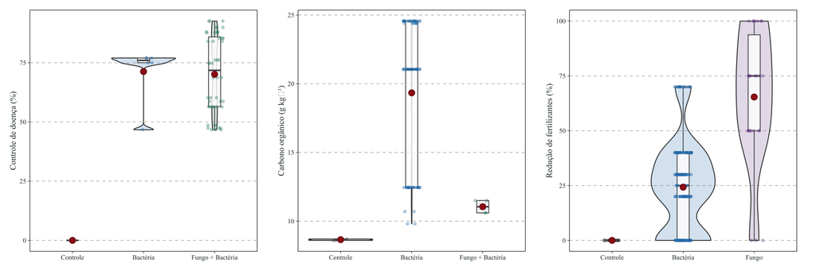

## 1.4 Principal component analysis

[figure not shown]

## 1.5 Response relative to the control

**Figure 7.** Variação percentual da mediana de cada classe de bioinsumo em relação à mediana do controle, para feijão (painel à esquerda) e arroz (painel à direita), para cada variável no eixo vertical. Pontos indicam a distância percentual entre a mediana da classe e a mediana do controle; barras horizontais indicam o primeiro e o terceiro quartil (Q1 e Q3) da própria classe, também expressos em relação à mediana do controle, e representam a dispersão interna da classe, não um intervalo de confiança. A linha tracejada vertical indica ausência de variação em relação ao controle. Cores identificam a classe comparada (azul-escuro para bactéria, roxo para fungo, verde para fungo mais bactéria). A síntese é descritiva, sem erro-padrão ou qualquer componente inferencial.

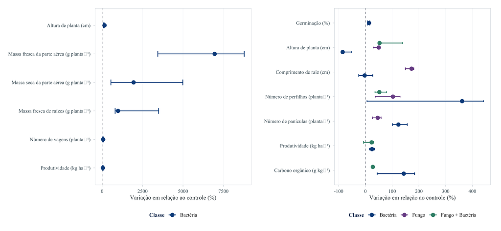

# 2 Dataset and reproducible code

The first six rows of the processed dataset used in the analyses are shown below.

Preview of the processed dataset (first six rows).

[output not shown]

PRISMA Protocol PROSPERO Registration R Code Data Base

Each resource opens in a new browser tab for viewing.

# 3 References

Pedersen, T. L. *patchwork*: the composer of plots. R package. Available at: https://CRAN.R-project.org/package=patchwork.

R Core Team. *R*: a language and environment for statistical computing. Vienna: R Foundation for Statistical Computing. Available at: https://www.R-project.org/.

Wickham, H. *ggplot2*: elegant graphics for data analysis. New York: Springer-Verlag, 2016.

Wickham, H.; François, R.; Henry, L.; Müller, K.; Vaughan, D. *dplyr*: a grammar of data manipulation. R package. Available at: https://CRAN.R-project.org/package=dplyr.

Wickham, H.; Vaughan, D.; Girlich, M. *tidyr*: tidy messy data. R package. Available at: https://CRAN.R-project.org/package=tidyr.

Xie, Y. *knitr*: a general-purpose package for dynamic report generation in R. R package. Available at: https://CRAN.R-project.org/package=knitr.